# IODS final project

Riku Turkki

3/6/2017

contact: riku.turkki@helsinki.fi

# Final project

This is the final course project for *Introduction to Open Data Science* MOOC organized in spring 2017.

# Abstract

# Specific research questions

1. Is there any association between female students’ final grade in math and alcohol consumption?
2. Is there any association between female students’ alcohol consumption and other selected variables?

# Description of the data set

I use the STUDENT ALCOHOL CONSUMPTION Data Set from [the UCI Machine Learning Repository](https://archive.ics.uci.edu/ml/datasets/STUDENT+ALCOHOL+CONSUMPTION). Only a part of the variables are used in this project. (Link to the data wrangling script: https://github.com/riturkki/IODS-final/blob/master/final_wrangle.Rmd)

The data set comprise information of 208 female students with following 8 variables:

- age - student’s age (numeric: from 15 to 22)
- Medu - mother’s education (numeric: 0 - none, 1 - primary education (4th grade), 2 - 5th to 9th grade, 3 - secondary education or 4 - higher education)
- Fedu - father’s education (numeric: 0 - none, 1 - primary education (4th grade), 2 - 5th to 9th grade, 3 - secondary education or 4 - higher education)
- studytime - weekly study time (numeric: 1 - <2 hours, 2 - 2 to 5 hours, 3 - 5 to 10 hours, or 4 - >10 hours)
- goout - going out with friends (numeric: from 1 - very low to 5 - very high)
- Dalc - workday alcohol consumption (numeric: from 1 - very low to 5 - very high)
- Walc - weekend alcohol consumption (numeric: from 1 - very low to 5 - very high)
- G3 - final grade (numeric: from 0 to 20, output target)

This particular data set is publicly available and it’s often used in learning r-programming and modelling.

Loading the data..

```r
data <- readRDS("my_data.rds")
```

# First glance

Let’s take a first look to the data set by visualizing it with pairs-plot:

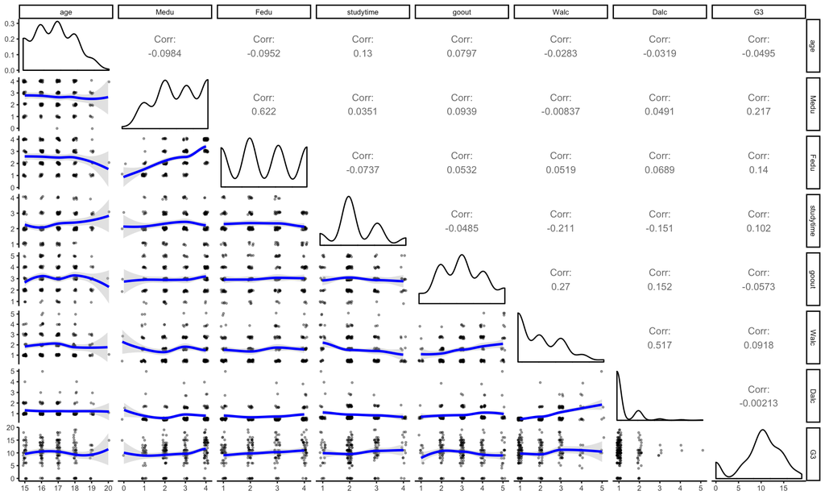

```r
library(tidyverse)
library(GGally)
library(modelr)
library(vcd)

set.seed(11)

myfn <- function(data, mapping, ...){
  p <- ggplot(data = data, mapping = mapping) +
    geom_jitter(width = 0.1, height = 0.1, size=.5, alpha = 1 / 3) +
    geom_smooth(fill="gray", color="blue", ...)
  p
}

data %>%
  ggpairs(lower = list(continuous = myfn),
          upper = list(continuous = wrap("cor", size = 3))) +
  theme_classic(base_size = 8)
```

The first thing one notice from the pairs-plot is that most of the lines are almost horizontal, indicating lack of correlation between variables. However, after looking at the plot for a while one can notice couple hints of co-variation. Parents educational levels seem to be positively correlated (r=0.62) and study time seems to increase, lightly, according students age (r=0.13). Regarding alcohol consumption, the strongest correlation is seen between variables describing consumption during weekend and work days (r=0.52). Additionally, variable describing how much a student goes out with her friends weakly correlates with alcohol consumption during weekends (r=0.27).

# Answering the first research question

Let’s inspect closer only the 3 most interesting variables *Walc*, *Dalc*, and *G3* regarding the first research question.

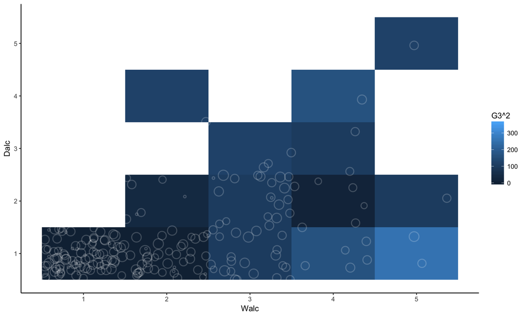

```r
data %>%
  ggplot( aes(x = Walc , y = Dalc)) +
  geom_tile(na.rm = TRUE, aes(fill = G3^2)) +
  geom_jitter(width = 0.5, height = 0.5, alpha = 1/5, col = "white",  shape = 21, stroke = 1, aes(size = G3), show.legend = FALSE) +
  theme_classic()
```

The figure above doesn’t reveal any obvious or unexpected patterns in the data. The plot, however, shows that drinking during working days is clearly less frequent than drinking alcohol during weekends. Lighter blue color in the plot indicates higher grade and darker lower. Most of the lower grades are located in bottom left corner of the plot, but so are majority of students as well.

In order to further study the association between alcohol consumption and math grade let’s fit a linear model to the data. Let’s also inspect the effect size of the two variables.

```r
mod <- lm(G3 ~ Walc + Dalc, data = data)
summary(mod)
```

```
##
## Call:
## lm(formula = G3 ~ Walc + Dalc, data = data)
##
## Residuals:
##     Min      1Q  Median      3Q     Max
## -10.154  -1.873   0.431   3.431   9.431
##
## Coefficients:
##             Estimate Std. Error t value Pr(>|t|)
## (Intercept)   9.5387     0.8010  11.909   <2e-16 ***
## Walc          0.5551     0.3552   1.563    0.120
## Dalc         -0.5248     0.6292  -0.834    0.405
## ---
## Signif. codes:  0 '***' 0.001 '**' 0.01 '*' 0.05 '.' 0.1 ' ' 1
##
## Residual standard error: 4.617 on 205 degrees of freedom
## Multiple R-squared:  0.01178,    Adjusted R-squared:  0.002138
## F-statistic: 1.222 on 2 and 205 DF,  p-value: 0.2969
```

```r
OR <- coef(mod) %>% exp
CI <- confint(mod) %>% exp
cbind(OR, CI)
```

```
##                       OR        2.5 %       97.5 %
## (Intercept) 1.388677e+04 2862.5039563 67368.418143
## Walc        1.742128e+00    0.8648632     3.509235
## Dalc        5.916653e-01    0.1711369     2.045542
```

Based on the R-squared statistics, the linear model explains only about 1% of the final grade. Furthermore, the fit is not statistically significant, meaning that weekend and work day alcohol consumption are not alone enough to explain the final grade.

Seems that the alcohol consumption does not explain the final grade, but let’s continue the analysis by investigating whether high use of alcohol would have a link with not getting through the course i.e. getting 0 points in the final test. So now we ask: ‘does drinking lead to failing in math course’. To do this, I’ll define two more variables *high_use* = (Walc + Dalc) > 3 and *no_points* = G3 == 0. To evaluate the assumption, let’s again inspect the effect size etc.

```r
data <- data %>%
  mutate(high_use = (Walc + Dalc) > 3) %>%
  mutate(no_points = G3 == 0)

mod <- glm(no_points ~ high_use, data = data, family = binomial)
summary(mod)
```

```
##
## Call:
## glm(formula = no_points ~ high_use, family = binomial, data = data)
##
## Deviance Residuals:
##     Min       1Q   Median       3Q      Max
## -0.5464  -0.5464  -0.5464  -0.3406   2.3985
##
## Coefficients:
##              Estimate Std. Error z value Pr(>|z|)
## (Intercept)   -1.8262     0.2472  -7.388 1.49e-13 ***
## high_useTRUE  -0.9922     0.5710  -1.738   0.0823 .
## ---
## Signif. codes:  0 '***' 0.001 '**' 0.01 '*' 0.05 '.' 0.1 ' ' 1
##
## (Dispersion parameter for binomial family taken to be 1)
##
##     Null deviance: 144.65  on 207  degrees of freedom
## Residual deviance: 141.09  on 206  degrees of freedom
## AIC: 145.09
##
## Number of Fisher Scoring iterations: 5
```

```r
OR <- coef(mod) %>% exp
CI <- confint(mod, level=0.95) %>% exp
cbind( OR, CI )
```

```
##                     OR     2.5 %    97.5 %
## (Intercept)  0.1610169 0.0961366 0.2547677
## high_useTRUE 0.3707777 0.1042268 1.0355903
```

The analysis shows that there’s no significant association between gaining no points and higher alcohol use. However, now the p-value (0.08) is lower than in the previous analysis . Interestingly the observed (not significant) association between high use and gaining no points seems to be protective.

# Answering the second research question

To continue with the second research question, let’s now divide the data set into separate training (70%) and test sets (30%). After this, we can fit a regression model to predict high use of alcohol (as defined above) based on the samples available in the training set and then later on, test the hypothesis in a separate test set. Let’s do a random 70% - 30% division for the sets and evaluate the model like we did earlier.

```r
set <- resample_partition(data, c(test = 0.3, train = 0.7))
mod <- glm(high_use ~ age + Medu + Fedu + studytime + goout + G3, data = set$train, family = binomial)
summary(mod)
```

```
##
## Call:
## glm(formula = high_use ~ age + Medu + Fedu + studytime + goout +
##     G3, family = binomial, data = set$train)
##
## Deviance Residuals:
##     Min       1Q   Median       3Q      Max
## -1.6101  -0.8940  -0.5793   1.0675   2.4394
##
## Coefficients:
##               Estimate Std. Error z value Pr(>|z|)
## (Intercept) -0.9655838  2.9763490  -0.324  0.74562
## age         -0.0003671  0.1701458  -0.002  0.99828
## Medu        -0.1487416  0.2306574  -0.645  0.51902
## Fedu         0.3426418  0.2304028   1.487  0.13698
## studytime   -0.8249146  0.2898760  -2.846  0.00443 **
## goout        0.3233010  0.1781210   1.815  0.06951 .
## G3           0.0503052  0.0462237   1.088  0.27646
## ---
## Signif. codes:  0 '***' 0.001 '**' 0.01 '*' 0.05 '.' 0.1 ' ' 1
##
## (Dispersion parameter for binomial family taken to be 1)
##
##     Null deviance: 181.94  on 145  degrees of freedom
## Residual deviance: 162.24  on 139  degrees of freedom
## AIC: 176.24
##
## Number of Fisher Scoring iterations: 4
```

```r
OR <- coef(mod) %>% exp
CI <- confint(mod, level=0.95) %>% exp
cbind( OR, CI )
```

```
##                    OR       2.5 %      97.5 %
## (Intercept) 0.3807608 0.001070571 134.4923958
## age         0.9996330 0.712864628   1.3950430
## Medu        0.8617917 0.544094675   1.3541773
## Fedu        1.4086641 0.901219741   2.2389884
## studytime   0.4382724 0.238949783   0.7512124
## goout       1.3816812 0.978682901   1.9752348
## G3          1.0515920 0.963416466   1.1566965
```

```r
preds <- predict(mod,newdata = set$test$data)
(cmat <- table(high_use = set$test$data$high_use, prediction = preds > 0))
```

```
##         prediction
## high_use FALSE TRUE
##    FALSE   129    8
##    TRUE     52   19
```

```r
OR <- oddsratio(cmat)
summary(OR)
```

```
##
## z test of coefficients:
##
##                       Estimate Std. Error z value  Pr(>|z|)
## FALSE:TRUE/FALSE:TRUE  1.77357    0.45234  3.9208 8.824e-05 ***
## ---
## Signif. codes:  0 '***' 0.001 '**' 0.01 '*' 0.05 '.' 0.1 ' ' 1
```

```r
cbind( coef(mod) %>% exp, confint(mod, level=0.95) %>% exp )
```

```
##                             2.5 %      97.5 %
## (Intercept) 0.3807608 0.001070571 134.4923958
## age         0.9996330 0.712864628   1.3950430
## Medu        0.8617917 0.544094675   1.3541773
## Fedu        1.4086641 0.901219741   2.2389884
## studytime   0.4382724 0.238949783   0.7512124
## goout       1.3816812 0.978682901   1.9752348
## G3          1.0515920 0.963416466   1.1566965
```

# Conclusions and discussion